# Measures of Central Location and Spread

Calculate for the following exercises

- the mean,
- the 5% trimmed mean,
- the median,
- the interquartile range,
- the 30%-quantile,
- the variance, the standard deviation, the coefficient of variation,
- the five-point-summary,
- and construct a boxplot.

Utility functions for IQR and CoV

```python
import pandas as pd

def calc_iqr(s: pd.Series):
    q1, q3 = s.quantile([0.25, 0.75])
    return q3 - q1

def calc_cov(s: pd.Series):
    return s.std() / s.mean()
```

## 1) Air Quality

Data unavailable.

## 2) Snow

The article “Snow Cover and Temperature Relationships in North America and Eurasia” (J. Climate and Applied Meteorology, 1983: 460–469) used statistical techniques to relate the amount of snow cover on each continent to average continental temperature. Data presented there included the following ten observations on October snow cover for Eurasia during the years 1970–1979 (in million km²): (Data: ex01.37) What would you report as a representative, or typical, value of October snow cover for this period

```python
import pyreadr

data = pyreadr.read_r('../data/devore7/ex01.37.rda')
df = data['ex01.37']
df.describe()
```

|  | C1 |
| --- | --- |
| count | 10.000000 |
| mean | 12.010000 |
| std | 4.390761 |
| min | 6.500000 |
| 25% | 9.400000 |
| 50% | 11.350000 |
| 75% | 14.000000 |
| max | 21.900000 |

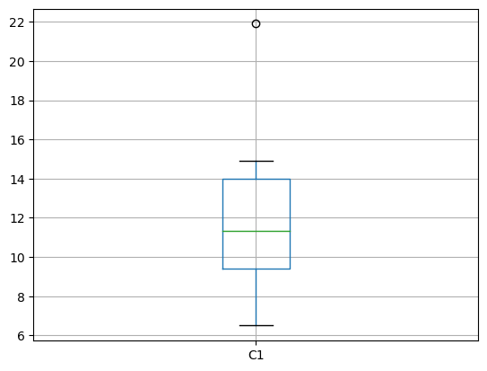

```python
df.boxplot(); None # <-- suppress output in Jupyter notebook
```

```python
from scipy import stats

mean = df['C1'].mean()
tmean = stats.trim_mean(df['C1'], .05)
median = df['C1'].median()
p30 = df['C1'].quantile(0.3)
var = df['C1'].var()
std = df['C1'].std()
cov = calc_cov(df['C1'])
iqr = calc_iqr(df['C1'])

mean, tmean, median, p30, var, std, cov, iqr
```

```
(12.010000000000002,
 12.01,
 11.35,
 9.76,
 19.278777777777776,
 4.3907605010724255,
 0.3655920483823834,
 4.600000000000001)
```

## 3) Escape Time

A sample of 26 offshore oil workers took part in a simulated escape exercise, resulting in the accompanying data on time (sec) to complete the escape (“Oxygen Consumption and Ventilation During Escape from an Offshore Platform,” Ergonomics, 1997: 281–292): (Data: ex01.36)

```python
import pyreadr

data = pyreadr.read_r('../data/devore7/ex01.36.rda')
df = data['ex01.36']
df.describe()
```

|  | C1 |
| --- | --- |
| count | 26.000000 |
| mean | 370.692308 |
| std | 24.358603 |
| min | 325.000000 |
| 25% | 359.000000 |
| 50% | 369.500000 |
| 75% | 391.250000 |
| max | 424.000000 |

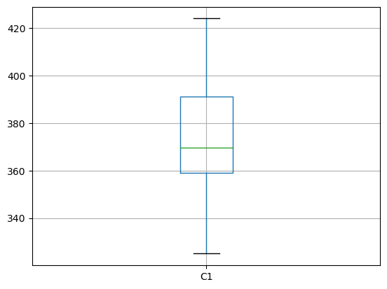

```python
df.boxplot(); None # <-- suppress output in Jupyter notebook
```

```python
from scipy import stats

mean = df['C1'].mean()
tmean = stats.trim_mean(df['C1'], .05)
median = df['C1'].median()
p30 = df['C1'].quantile(0.3)
var = df['C1'].var()
std = df['C1'].std()
cov = calc_cov(df['C1'])
iqr = calc_iqr(df['C1'])

mean, tmean, median, p30, var, std, cov, iqr
```

```
(370.6923076923077,
 370.375,
 369.5,
 361.0,
 593.3415384615386,
 24.358602966129617,
 0.06571110988995331,
 32.25)
```

## 4) Crankcase Lubricants

The article “A Thin-Film Oxygen Uptake Test for the Evaluation of Automotive Crankcase Lubricants” (Lubric. Engr., 1984: 75–83) reported the following data on oxidation-induction time (min) for various commercial oils: (Data: ex01.51)

```python
import pyreadr
from scipy import stats

data = pyreadr.read_r('../data/devore7/ex01.51.rda')
df = data['ex01.51']
df.describe()

df['C1'] == df.loc[:, 'C1']

df.mean()
df.median()
df['C1'].median()
```

```
132.0
```

## 4) Crankcacse Lubricants (cont.)

```python
std = df['C1'].std()
mean = df['C1'].mean()

stats.trim_mean(df['C1'], .05)
cov = std / mean
cov

q1, q3 = df['C1'].quantile([0.25, 0.75])
iqr = q3 - q1
iqr
```

```
48.5
```

## 4) Crankcacse Lubricants (cont.)

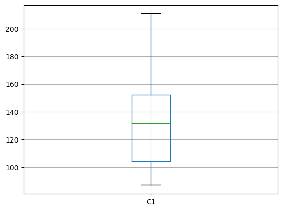

```python
df.boxplot(); None # <-- suppress output in Jupyter notebook
```